# HW5

Yuelin Long

March 10, 2019

```r
#Load libraries
library(tidyverse)
library(pscl)
```

## Problem 1

#### Question 1

```r
#Load raw data
crab_data = read.delim("HW5-crab.txt", sep = "") %>%
  select(-number)

m1.fit = glm(Sa~W, family=poisson, data=crab_data)
summary(m1.fit)
```

```
##
## Call:
## glm(formula = Sa ~ W, family = poisson, data = crab_data)
##
## Deviance Residuals:
##     Min       1Q   Median       3Q      Max
## -2.8526  -1.9884  -0.4933   1.0970   4.9221
##
## Coefficients:
##             Estimate Std. Error z value Pr(>|z|)
## (Intercept) -3.30476    0.54224  -6.095  1.1e-09 ***
## W            0.16405    0.01997   8.216  < 2e-16 ***
## ---
## Signif. codes:  0 '***' 0.001 '**' 0.01 '*' 0.05 '.' 0.1 ' ' 1
##
## (Dispersion parameter for poisson family taken to be 1)
##
##     Null deviance: 632.79  on 172  degrees of freedom
## Residual deviance: 567.88  on 171  degrees of freedom
## AIC: 927.18
##
## Number of Fisher Scoring iterations: 6
```

```r
#Goodness of fit
m1.fit$deviance
```

```
## [1] 567.8786
```

```r
n = nrow(crab_data)
p1 = 2
df = n-p1
qchisq(0.05,df)
```

```
## [1] 141.76
```

```r
pval=1-pchisq(m1.fit$deviance,df=df)
pval
```

```
## [1] 0
```

Intepretation:

- Intercept b0: Since the width of carapace cannot be 0, the intercept has no actual meaning.
- Coefficient b1: With 1 unit change in carapace width, the log rate ratio of the number of satellites of female crab would increase by 0.16405.

Goodness of fit: The deviance is far greater than critical value. Therefore, reject the null hypothesis and conclude that the fit is bad. The small p value also confirms it.

# Question 2

```r
m2.fit = glm(Sa~W+Wt, family=poisson, data=crab_data)
summary(m2.fit)
```

```
##
## Call:
## glm(formula = Sa ~ W + Wt, family = poisson, data = crab_data)
##
## Deviance Residuals:
##     Min       1Q   Median       3Q      Max
## -2.9308  -1.9705  -0.5481   0.9700   4.9905
##
## Coefficients:
##             Estimate Std. Error z value Pr(>|z|)
## (Intercept) -1.29168    0.89929  -1.436  0.15091
## W            0.04590    0.04677   0.981  0.32640
## Wt           0.44744    0.15864   2.820  0.00479 **
## ---
## Signif. codes:  0 '***' 0.001 '**' 0.01 '*' 0.05 '.' 0.1 ' ' 1
##
## (Dispersion parameter for poisson family taken to be 1)
##
##     Null deviance: 632.79  on 172  degrees of freedom
## Residual deviance: 559.89  on 170  degrees of freedom
## AIC: 921.18
##
## Number of Fisher Scoring iterations: 6
```

```r
#Goodness of fit
m2.fit$deviance
```

```
## [1] 559.8852
```

```r
p2 = 3
df = n-p2
qchisq(0.05,df)
```

```
## [1] 140.8492
```

```r
pval=1-pchisq(m2.fit$deviance,df=df)
pval
```

```
## [1] 0
```

Intepretation:

- Intercept b0: Since the width of carapace cannot be 0, nor can the weight be 0, the intercept has no actual meaning.
- Coefficient of W (b1): Given weight fixed, with 1 unit change in carapace width, the log rate ratio of the number of satellites of female crab would increase by 0.04590.
- Coefficient of Wt (b2): Given catapace width fixed, with 1 unit change in weight, the log rate ratio of the number of satellites of female crab would increase by 0.44744.

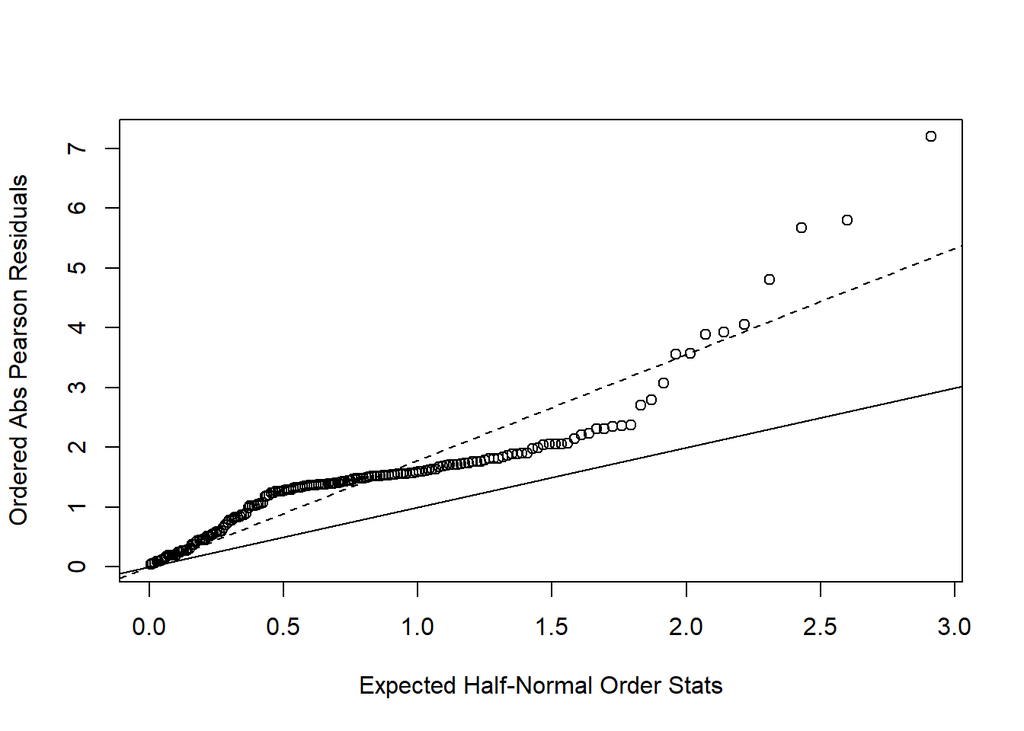

```r
#Estimate over-dispersion parameters
res.p2=residuals(m2.fit,type='pearson',data=crab_data)
G2=sum(res.p2^2)
phi=G2/df

#Check whether over dispersion exist - Half normal plot
plot(qnorm((n+1:n+0.5)/(2*n+1.125)),sort(abs(res.p2)),xlab='Expected Half-Normal Order Stats',ylab='Ordered Abs Pearson Residuals')
abline(a=0,b=1)
abline(a=0,b=sqrt(phi),lty=2)
```

The data fit the dotted line better, and the slope of dotted line is quite different from the solid line. This indicates that there is over dispersion.

```r
#Fit model adjusted for over dispersion
summary(m2.fit,dispersion=phi)
```

```
##
## Call:
## glm(formula = Sa ~ W + Wt, family = poisson, data = crab_data)
##
## Deviance Residuals:
##     Min       1Q   Median       3Q      Max
## -2.9308  -1.9705  -0.5481   0.9700   4.9905
##
## Coefficients:
##             Estimate Std. Error z value Pr(>|z|)
## (Intercept) -1.29168    1.59771  -0.808    0.419
## W            0.04590    0.08309   0.552    0.581
## Wt           0.44744    0.28184   1.588    0.112
##
## (Dispersion parameter for poisson family taken to be 3.156449)
##
##     Null deviance: 632.79  on 172  degrees of freedom
## Residual deviance: 559.89  on 170  degrees of freedom
## AIC: 921.18
##
## Number of Fisher Scoring iterations: 6
```

Intepretation (same as unadjusted):

- Intercept b0: Since the width of carapace cannot be 0, nor can the weight be 0, the intercept has no actual meaning.
- Coefficient of W (b1): Given weight fixed, with 1 unit change in carapace width, the log rate ratio of the number of satellites of female crab would increase by 0.04590.
- Coefficient of Wt (b2): Given catapace width fixed, with 1 unit change in weight, the log rate ratio of the number of satellites of female crab would increase by 0.44744.

## Problem 2

#### Question 1

```r
#Load raw data
para_data = read.delim("HW5-parasite.txt", sep = "") %>%
  select(-Sample, -starts_with("omit")) %>%
  na.omit() %>%
  dplyr::mutate(Area = factor(Area, levels = rep(1:4)),
         Year = factor(Year, levels = rep(1999:2001)))

m1.fit = glm(Intensity~., family=poisson, data=para_data)
summary(m1.fit)
```

```
##
## Call:
## glm(formula = Intensity ~ ., family = poisson, data = para_data)
##
## Deviance Residuals:
##     Min       1Q   Median       3Q      Max
## -9.3632  -2.7158  -2.0142  -0.4731  30.2492
##
## Coefficients:
##               Estimate Std. Error z value Pr(>|z|)
## (Intercept)  2.6431709  0.0542838  48.692  < 2e-16 ***
## Year2000     0.6702801  0.0279823  23.954  < 2e-16 ***
## Year2001    -0.2181393  0.0287535  -7.587 3.29e-14 ***
## Length      -0.0284228  0.0008809 -32.265  < 2e-16 ***
## Area2       -0.2119557  0.0491691  -4.311 1.63e-05 ***
## Area3       -0.1168602  0.0428296  -2.728  0.00636 **
## Area4        1.4049366  0.0356625  39.395  < 2e-16 ***
## ---
## Signif. codes:  0 '***' 0.001 '**' 0.01 '*' 0.05 '.' 0.1 ' ' 1
##
## (Dispersion parameter for poisson family taken to be 1)
##
##     Null deviance: 25797  on 1190  degrees of freedom
## Residual deviance: 19153  on 1184  degrees of freedom
## AIC: 21089
##
## Number of Fisher Scoring iterations: 7
```

Intepretation:

- Intercept: Since the length of the fish can’t be 0, the intercept has no actual meaning.
- Coefficient of Year 2000: Given length of fish and area fixed, the log odds rate ratio of for Year 2000 verse year 1999 for the number of parasites is 0.6702801.
- Coefficient of Year 2001: Given length of fish and area fixed, the log odds rate of the increase of number of parasites is -0.2181393 for Year 2001 verse year 1999.
- Coefficient of Length: Given year and area fixed, every 1 unit increase in the length of fish would increase the log rate ratio of the number of parasites by -0.0284228.
- Coefficient of Area2: Given year and length of fish fixed, the log rate ratio of number of parasite would increase by -0.2119557 in area 2 versus area 1.
- Coefficient of Area3: Given year and length of fish fixed, the log rate ratio of number of parasite would increase by -0.1168602 in area 3 versus area 1.
- Coefficient of Area4: Given year and length of fish fixed, the log rate ratio of number of parasite would increase by 1.4049366 in area 4 versus area 1.

#### Question 2

```r
#Goodness of fit
m1.fit$deviance
```

```
## [1] 19152.8
```

```r
n = as.numeric(nrow(para_data))
p1 = ncol(para_data) - 1
df = n-p1
qchisq(0.05,df)
```

```
## [1] 1108.976
```

```r
pval=1-pchisq(m1.fit$deviance,df=df)
pval
```

```
## [1] 0
```

Goodness of fit: The deviance is far greater than critical value. Therefore, reject the null hypothesis and conclude that the fit is bad. The small p value also confirms it.

#### Question 3

```r
m2.fit = zeroinfl(Intensity ~ Year + Length + Area | Year + Length + Area, data = para_data)
summary(m2.fit)
```

```
##
## Call:
## zeroinfl(formula = Intensity ~ Year + Length + Area | Year + Length +
##     Area, data = para_data)
##
## Pearson residuals:
##     Min      1Q  Median      3Q     Max
## -2.1278 -0.8265 -0.5829 -0.1821 25.4837
##
## Count model coefficients (poisson with log link):
##               Estimate Std. Error z value Pr(>|z|)
## (Intercept)  3.8431714  0.0583793  65.831  < 2e-16 ***
## Year2000     0.3919831  0.0282952  13.853  < 2e-16 ***
## Year2001    -0.0448455  0.0296057  -1.515 0.129833
## Length      -0.0368067  0.0009747 -37.762  < 2e-16 ***
## Area2        0.2687835  0.0500467   5.371 7.85e-08 ***
## Area3        0.1463173  0.0439485   3.329 0.000871 ***
## Area4        0.9448068  0.0368342  25.650  < 2e-16 ***
##
## Zero-inflation model coefficients (binomial with logit link):
##              Estimate Std. Error z value Pr(>|z|)
## (Intercept)  0.552585   0.275762   2.004  0.04509 *
## Year2000    -0.752119   0.172965  -4.348 1.37e-05 ***
## Year2001     0.456535   0.143962   3.171  0.00152 **
## Length      -0.009889   0.004629  -2.136  0.03266 *
## Area2        0.718676   0.189552   3.791  0.00015 ***
## Area3        0.657708   0.167402   3.929 8.53e-05 ***
## Area4       -1.022868   0.188201  -5.435 5.48e-08 ***
## ---
## Signif. codes:  0 '***' 0.001 '**' 0.01 '*' 0.05 '.' 0.1 ' ' 1
##
## Number of iterations in BFGS optimization: 22
## Log-likelihood: -6950 on 14 Df
```

Intepretation:

For Poisson model:

Intepretation:

- Intercept: Since the length of the fish can’t be 0, the intercept has no actual meaning.
- Coefficient of Year 2000: Given length of fish and area fixed, the log rate ratio of number of parasite would increase by 0.3919831 for Year 2000 verse year 1999.
- Coefficient of Year 2001: Given length of fish and area fixed, the log rate ratio of number of parasite would increase by -0.0448455 for Year 2001 verse year 1999.
- Coefficient of Length: Given year and area fixed, every 1 unit increase in the length of fish would increase the log rate ratio of number of parasites by -0.0368067.
- Coefficient of Area2: Given year and length of fish fixed, the log rate ratio of number of parasite would increase by 0.2687835 in area 2 versus area 1.
- Coefficient of Area3: Given year and length of fish fixed, the log rate ratio of number of parasite would increase by 0.1463173 in area 3 versus area 1.
- Coefficient of Area4: Given year and length of fish fixed, the log rate ratio of number of parasite would increase by 0.9448068 in area 4 versus area 1.

For Binomial model:

- Intercept b0: Since the length of the fish can’t be 0, the intercept has no actual meaning.
- Coefficient of Year 2000: Given length of fish and area fixed, the log odds ratio of susceptible to parasites over not susceptible to parasites is -0.752119 for Year 2000 verse year 1999.
- Coefficient of Year 2001: Given length of fish and area fixed, the log odds ratio of susceptible to parasites over not susceptible to parasites is 0.456535 for Year 2001 verse year 1999.
- Coefficient of Length: Given year and area fixed, for every 1 unit change in length of the fish, the log odds ratio of susceptible to parasites over not susceptible to parasites would be -0.009889.
- Coefficient of Area2: Given year and length of fish fixed, the log odds ratio of susceptible to parasites over not susceptible to parasites would be 0.718676 in area 2 versus area 1.
- Coefficient of Area3: Given year and length of fish fixed, the log odds ratio of susceptible to parasites over not susceptible to parasites would be 0.657708 in area 3 versus area 1.
- Coefficient of Area4: Given year and length of fish fixed, the log odds ratio of susceptible to parasites over not susceptible to parasites would be -1.022868 in area 4 versus area 1.